# Maps and plots with ColOpenData

**ColOpenData** can be used to access open geospatial data from Colombia. This data is retrieved from the National Geostatistical Framework (MGN), published by the National Administrative Department of Statistics (DANE). The MGN contains the political-administrative division and is used to reference census statistical information.

Available levels of aggregation come from the official spatial division provided by DANE, with their names corresponding to:

| Code | Level | Name |
| --- | --- | --- |
| DPTO | Department | DANE_MGN_2018_DPTO |
| MPIO | Municipality | DANE_MGN_2018_MPIO |
| MPIOCL | Municipality including Class | DANE_MGN_2018_MPIOCL |
| MZN | Block | DANE_MGN_2018_MZN |
| SECR | Rural Sector | DANE_MGN_2018_SECR |
| SECU | Urban Sector | DANE_MGN_2018_SECU |
| SETR | Rural Section | DANE_MGN_2018_SETR |
| SETU | Urban Section | DANE_MGN_2018_SETU |
| ZU | Urban Zone | DANE_MGN_2018_ZU |

In this vignette you will learn:

1. How to download geospatial data using **ColOpenData**.
2. How to use census data included in geospatial datasets.
3. How to visualize spatial data using **leaflet** and **ggplot2**.

We will be using geospatial data at the level of Department (“dpto”) and we will calculate the percentage of dwellings with internet connection at each department. Later, we will build some plots using the previously mentioned approaches for dynamic and static plots.

We will start by importing the needed libraries.

```r
library(ColOpenData)
library(dplyr)
library(sf)
library(ggplot2)
library(leaflet)
```

**Disclaimer: all data is loaded to the environment in the user’s R session, but is not downloaded to user’s computer. Spatial datasets can be very long and might take a while to be loaded in the environment**

## Downloading geospatial data

First, we download the data using the function `download_geospatial()`, including the geometries and the census related information. The `simplified` parameter is used to download a lighter version, since simple plots do not require precise spatial information.

```r
dpto <- download_geospatial(
  spatial_level = "dpto",
  simplified = TRUE,
  include_geom = TRUE,
  include_cnpv = TRUE
)
```

```
#> Original data is retrieved from the National Administrative Department
#> of Statistics (Departamento Administrativo Nacional de Estadística -
#> DANE).
#> Reformatted by package authors.
#> Stored by Universidad de Los Andes under the Epiverse TRACE iniative.
```

```r
head(dpto)
```

```
#> # A tibble: 6 × 89
#>   codigo_departamento departamento    version    area latitud longitud encuestas
#>   <chr>               <chr>             <dbl>   <dbl>   <dbl>    <dbl>     <dbl>
#> 1 18                  Caquetá            2018 9.01e10   0.799    -74.0    163381
#> 2 19                  Cauca              2018 3.12e10   2.40     -76.8    622959
#> 3 86                  Putumayo           2018 2.60e10   0.452    -75.9    147797
#> 4 76                  Valle del Cauca    2018 2.07e10   3.86     -76.5   1674673
#> 5 94                  Guainía            2018 7.13e10   2.73     -68.8     13059
#> 6 99                  Vichada            2018 1.00e11   4.71     -69.4     24915
#> # ℹ 82 more variables: enc_etnico <dbl>, enc_no_etnico <dbl>,
#> #   enc_resguardo_indigena <dbl>, enc_comun_negras <dbl>,
#> #   enc_area_protegida <dbl>, enc_area_no_protegida <dbl>, un_vivienda <dbl>,
#> #   un_mixto <dbl>, un_no_res <dbl>, un_lea <dbl>,
#> #   un_mixto_no_res_industria <dbl>, un_mixto_no_res_comercio <dbl>,
#> #   un_mixto_no_res_servicios <dbl>, un_mixto_no_res_agro <dbl>,
#> #   un_mixto_no_res_sin_info <dbl>, un_no_res_industria <dbl>, …
```

To understand which column contains the internet related information, we will need the corresponding dataset dictionary. To download the dictionary we can use the `geospatial_dictionary()` function. This function uses as parameters the dataset name to download the associated information and language of this information. For further information please refer to the documentation on dictionaries previously mentioned.

```r
dict <- geospatial_dictionary(spatial_level = "dpto", language = "EN")

head(dict)
```

```
#> # A tibble: 6 × 4
#>   variable            type         length description
#>   <chr>               <chr>         <dbl> <chr>
#> 1 codigo_departamento Text              2 Department code
#> 2 departamento        Text            250 Department name
#> 3 version             Long Integer     NA Year of validity of the department in…
#> 4 area                Double           NA Department area in square meters (Pla…
#> 5 latitud             Double           NA Centroid latitude coordinate of the d…
#> 6 longitud            Double           NA Centroid longitude coordinate of the …
```

To calculate the percentage of dwellings with internet connection, we will need to know the number of dwellings with internet connection and the total of dwellings in each department. From the dictionary, we get that the number of dwellings with internet connection is viv_internet and the total of dwellings is viviendas. We will calculate the percentage as follows:

```r
internet_cov <- dpto %>% mutate(internet = round(viv_internet / viviendas, 2))
```

## Static plots (ggplot2)

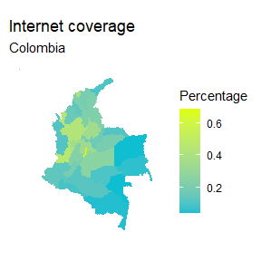

```r
ggplot(data = internet_cov) +
  geom_sf(mapping = aes(fill = internet), color = NA) +
  theme_minimal() +
  theme(
    plot.background = element_rect(fill = "white", colour = "white"),
    panel.background = element_rect(fill = "white", colour = "white"),
    panel.grid = element_blank(),
    axis.text = element_blank(),
    axis.ticks = element_blank()
  ) +
  scale_fill_gradient("Percentage", low = "#10bed2", high = "#deff00") +
  ggtitle(
    label = "Internet coverage",
    subtitle = "Colombia"
  )
```

## Dynamic plots (leaflet)

For dynamic plots, we can use [`leaflet`](https://rstudio.github.io/leaflet/), which is an open-source library for interactive maps. To create the same plot we first will create the color palette.

```r
colfunc <- colorRampPalette(c("#10bed2", "#deff00"))
pal <- colorNumeric(
  palette = colfunc(100),
  domain = internet_cov[["internet"]]
)
```

With the previous color palette we can generate the interactive plot. The package also includes open source maps for the base map like [OpenStreetMap](https://www.openstreetmap.org/#map=5/4.632/-74.299) and [CartoDB](https://carto.com/basemaps). For further details on `leaflet`, please refer to the package’s [documentation](https://rstudio.github.io/leaflet/reference/index.html).

```r
leaflet(internet_cov) %>%
  addProviderTiles(providers$CartoDB.Positron) %>%
  addPolygons(
    stroke = TRUE,
    weight = 0,
    color = NA,
    fillColor = ~ pal(internet_cov[["internet"]]),
    fillOpacity = 1,
    popup = paste0(internet_cov[["internet"]])
  ) %>%
  addLegend(
    position = "bottomright",
    pal = pal,
    values = ~ internet_cov[["internet"]],
    opacity = 1,
    title = "Internet Coverage"
  )
```

[interactive chart not shown]